# GPU Computing in Python with CuPy

Alex Reustle

[video not shown]

## Agenda

- Quick CuPy Overview
  - Acceleration Benchmarks
- GPU Hardware Fundamentals
  - Hardware Acceleration
  - CPU vs GPU
  - Memory
  - Nvidia
- GPU Software
  - Parallelism
  - Algorithms
- GPU Programming Models
  - Libraries - Cupy
    - Numpy-style vector programming
  - Directives - OpenACC
  - Languages - Cuda
- Applications
  - N-Body Simulation - MatMul
  - 2D Power Spectrum - FFT
  - Emission Spectral lines - Linear Solver

# CuPy : NumPy-like API for GPUs

https://cupy.chainer.org/

## Get CuPy from conda or pip

`conda install -c conda-forge cupy`

`pip install cupy`  
`pip install cupy-cuda102`

# How do I write Python Code for my GPU?

Don't.

Just write numpy code for your CPU.

```python
# saxpy - single precision scalar a times vector x plus vector y
import numpy as np

N = 1024

a = 661.0

x = np.random.normal(0, 1, N)
y = np.random.normal(0, 1, N)

a*x + y
```

```
array([ 277.20334108,   43.17543752,  120.94956957, ...,  762.13406675,
       -448.03309227, 1191.14132007])
```

```python
# saxpy - single precision scalar a times vector x plus vector y
import cupy as cp

N = 1024

a = 661.0

x = cp.random.normal(0, 1, N)
y = cp.random.normal(0, 1, N)

a*x + y
```

```
array([   94.79368662,    76.08294046,   534.11500058, ...,
        -412.23808028, -1113.34835287,  -279.149126  ])
```

[figure not shown]

# GPU Hardware Deep Dive

What does 21.1 billion transistors get you?

[figure not shown]

Nvidia Tesla V100. There are 2 of these GPUs in gs66-grain.

## Hardware Accelerator

- A GPU is a seperate piece of computer hardware that performs specialized tasks faster(?) than the CPU can.
- GPU stands for **Graphics Processing Unit** (Graphics Card). Originally used to compute 2D projections of 3D objects.
- Graphics computations are inherently parallel (lots of independent pixels).
- GPUs are optimized for parallel computations.
- Parallel computations can benefit far more than just Graphics: **GPGPU**: General Purpose GPU

## CPU vs GPU

[figure not shown]

image source: Nvidia

[figure not shown]

image source: Nvidia

### How are the chips different

[figure not shown]

## Device Memory

### GPUs and CPUs have different memory spaces. You have to explicitly move data between them!

[figure not shown]

image source: Nvidia

## Nvidia and other Chip makers

# GPU Software Parallelism

[figure not shown]

image source: Nvidia

## What is Parallelism?

Doing multiple operations simultaneously.

Multiple kinds of parallelism exist

Task Parallelism: Do unrelated tasks simultaneously - Walk & Chew Gum.

Data Parallelism: Split Big problem into related smaller problems and do each smaller problem concurrently - Divide & Conquor.

GPUs are Data Parallel devices.

[figure not shown]

## Why is it necessary?

It's not.

## Why Not?

Every parallel algorithm can be performed sequentially. But not every sequential algorithm can be performed in parallel. In many cases GPU computing is not useful.

## When are GPUs useful?

Some problems are inherently easy to parallelize and are called **embarassingly parallel** problems.

SAXPY is an embarassingly parallel problem. The same operation can be applied to multiple data independently and in parallel.

$ \begin{bmatrix} y_0 \\ y_1 \\ y_2 \\ y_3 \\ y_4 \\ y_5 \\ y_6 \\ y_7 \end{bmatrix} = \alpha * \begin{bmatrix} x_0 \\ x_1 \\ x_2 \\ x_3 \\ x_4 \\ x_5 \\ x_6 \\ x_7 \end{bmatrix} + \begin{bmatrix} y_0 \\ y_1 \\ y_2 \\ y_3 \\ y_4 \\ y_5 \\ y_6 \\ y_7 \end{bmatrix} \quad\quad\quad \begin{array}{c} \begin{bmatrix}y_0\end{bmatrix} =\\ \begin{bmatrix}y_1\end{bmatrix} =\\ \begin{bmatrix}y_2\end{bmatrix} =\\ \begin{bmatrix}y_3\end{bmatrix} =\\ \begin{bmatrix}y_4\end{bmatrix} =\\ \begin{bmatrix}y_5\end{bmatrix} =\\ \begin{bmatrix}y_6\end{bmatrix} =\\ \begin{bmatrix}y_7\end{bmatrix} = \end{array} \begin{array}{c} \alpha * \begin{bmatrix}x_0\end{bmatrix} + \\ \alpha * \begin{bmatrix}x_1\end{bmatrix} + \\ \alpha * \begin{bmatrix}x_2\end{bmatrix} + \\ \alpha * \begin{bmatrix}x_3\end{bmatrix} + \\ \alpha * \begin{bmatrix}x_4\end{bmatrix} + \\ \alpha * \begin{bmatrix}x_5\end{bmatrix} + \\ \alpha * \begin{bmatrix}x_6\end{bmatrix} + \\ \alpha * \begin{bmatrix}x_7\end{bmatrix} + \end{array} \begin{array}{c} \begin{bmatrix}y_0\end{bmatrix} \\ \begin{bmatrix}y_1\end{bmatrix} \\ \begin{bmatrix}y_2\end{bmatrix} \\ \begin{bmatrix}y_3\end{bmatrix} \\ \begin{bmatrix}y_4\end{bmatrix} \\ \begin{bmatrix}y_5\end{bmatrix} \\ \begin{bmatrix}y_6\end{bmatrix} \\ \begin{bmatrix}y_7\end{bmatrix} \end{array} $

```python
a*x + y
```

```
array([   94.79368662,    76.08294046,   534.11500058, ...,
        -412.23808028, -1113.34835287,  -279.149126  ])
```

## Some Problems are Not Embarassingly Parallel, but can still be accelerated.

Lots of other linear algebraic operations have fast GPU algorithms:

Matrix Operations (GEMM), Fourier Transforms, Linear Solvers ($Ax = b$)

If you can vectorize your problem, or formulate it in terms of these and other primitive operations you can likely benefit from GPUs.

### Example: Reduction

What is the Sum of the first N positive integers?

$x = 1 + 2 + 3 + 4 + 5 + 6 + 7 + 8$

Sequential (CPU):  
$\begin{array}{c} x = 1 + 2 \\ x = x + 3 \\ \vdots \\ x = x + 8 \end{array}$

Parallel (GPU):  
$\begin{array}{c} x = 1 + 2 \quad\quad y = 3 + 4 \quad\quad z = 5 + 6 \quad\quad w = 7 + 8 \\ x = x + y \quad\quad z = z + w \\ x = x + z \end{array}$

This is an example of Accumulation (Reduction), which for large numbers of accumulates is a well parallelizable problem.

### Example: General Matrix Multiplication (GeMM)

Important well studied problem with non-trivial parallel algorithm

[figure not shown]

## When are GPUs NOT useful?

Often! Useful on big sets of VERY Parallelizable problems. Some Problems which are inherently sequential cannot be reasonably sped up by GPUs.

### Example: Fibonacci Sequence

$F_{0}=0,\quad F_{1}=1, \quad F_{n}=F_{n-1}+F_{n-2}$ for n > 1.

${\displaystyle 0,\;1,\;1,\;2,\;3,\;5,\;8,\;13,\;21,\;34,\;55,\;89,\;144,\;\ldots }$

Determining the $N^{th}$ Fibonacci number (via this formulation) requires that you know both $F_{n-1}$ and $F_{n-2}$, which in turn require knowledge of earlier numbers in the sequence.

note: there is a way to parallelize generating large Fibonacci numbers and is left as an exercise to the reader.

### Amdahl's Law

Many tasks can be broken up into two component parts, the parallel and sequential parts. As more processors are thrown at a problem the amount of time taken by the parallel part shrinks, but the sequential part remains unchanged. The performance speedup you can get from parallelism is dominated by the fraction of the problem that is sequential.

Amdahl's law can be formulated in the following way:

${\displaystyle S_{\text{latency}}(s)={\frac {1}{(1-p)+{\frac {p}{s}}}}}$

where

$S_{\text{latency}}$ is the theoretical speedup of the execution of the whole task; \ s is the speedup of the part of the task that benefits from improved system resources; \ p is the proportion of execution time that the part benefiting from improved resources originally occupied.

[figure not shown]

## GPUs are BAD at Conditional Branching

`if else` blocks for different instruction paths are not well suited for GPUs. CPUs devote lots of silicon to handling branch control for logic and predictive execution, but GPUs instead dedicate their silicon to more parallel cores.

Try to avoid branching code in your GPU algorithms.

# Programming Models

[figure not shown]

## Libraries: Numpy and CuPy

Numpy already gives us an excellent mechanism for expressing vectorized code succinctly and efficiently. It relies on heavily optimized compiled C and Fortran routines to provide excellent performance relative to pure python.

CuPy is a new open source library from Nvida and Preferred Networks that aims to bring the Numpy and Scipy interface to GPUs. At the moment it's very limited and doesn't implement most of the numpy + scipy functions.

But what it can do it does very well.

```python
# Create Numpy array On CPU
x = np.array([0,1,2,3,4])
type(x)
```

```
numpy.ndarray
```

```python
# Create Cupy array On GPU
y = cp.array([0,1,2,3,4])
type(y)
```

```
cupy.core.core.ndarray
```

```python
# ERROR: Cupy and Numpy cannot interact directly (Data in different memories)
x + y
```

```
---------------------------------------------------------------------------
TypeError                                 Traceback (most recent call last)
<ipython-input-9-f470fc4dec4b> in <module>
      1 # ERROR: Cupy and Numpy cannot interact directly (Data in different memories)
----> 2 x + y

cupy/core/core.pyx in cupy.core.core.ndarray.__array_ufunc__()

cupy/core/_kernel.pyx in cupy.core._kernel.ufunc.__call__()

cupy/core/_kernel.pyx in cupy.core._kernel._preprocess_args()

TypeError: Unsupported type <class 'numpy.ndarray'>
```

```python
# Use cupy.asarray to send CPU data to GPU memory
x = cp.asarray(x)
z = x+y
type(z)
```

```
cupy.core.core.ndarray
```

```python
# use cupy.asnumpy to bring GPU data back to CPU memory
x = cp.asnumpy(x)
y = cp.asnumpy(y)
z = x+y
type(z)
```

```
numpy.ndarray
```

```python
# Use cp.get_array_module to automatically detect which type is used for generic code

x = np.arange(5)
xp = cp.get_array_module(x) #
y = xp.ones_like(x)
print(x + y)
print(type(x+y))
```

```
[1 2 3 4 5]
<class 'numpy.ndarray'>
```

```python
x = cp.arange(5)
xp = cp.get_array_module(x) #
y = xp.ones_like(x)
print(x + y)
print(type(x+y))
```

```
[1 2 3 4 5]
<class 'cupy.core.core.ndarray'>
```

## CPU/GPU Synchronization

- Because the GPU is a separate device it may perform work independently of the CPU.
- All GPU kernels are launched asynchronously. Control retruns immediately to the CPU.
- Do other, task parallel work on CPU while waiting for result.
- CuPy mostly handles synchronization invisibly: will wait for results to be ready before proceeding.
  - Doesn't work for performance timing
- User can add explicit command to wait for GPU with `cp.cuda.stream.get_current_stream().synchronize()`

```python
x = cp.random.normal(0, 1, 100_000_000)
y = cp.random.normal(0, 1, 100_000_000)

tstart = time.time()
a*x + y
cp.cuda.stream.get_current_stream().synchronize()
tstop = time.time()

print(f"ODE solver runtime: {(tstop - tstart)} seconds. ")
```

```
ODE solver runtime: 0.17853212356567383 seconds.
```

# CuPy API a work in progress

Still a lot of unimplemented classes and methods. https://docs-cupy.chainer.org/en/stable/reference/comparison.html

## OpenACC Directives

[figure not shown]

## Nvidia and Cuda

Nvidia is the leading global producer of high performance GPUs, and Cuda is the API they have created to program those GPUs. Cuda is free but not open source, as are many proprietary libraries written by Nvidia. This is becoming less true as they are starting to open up more of their code base. Cuda is written for C, C++ and Fortran.

[figure not shown]

# N-Body Problem

Given N massive bodies in 3D space affected by a simple Newtonian gravitational field how will the positions, and velocities of the bodies evolve as the system progresses in time?

Approach: Solve a set of non-linear second order ordinary differential equations.

$\quad\quad\quad\quad\begin{array}{c} \dot{x_i} = v_i \\ \dot{v_i} = a_i \end{array}$  
Where:

- $x_i$ is the 3D **position** vector for the $i^{th}$ body.
- $v_i$ is the 3D **velocity** vector for the $i^{th}$ body
- $a_i$ is the 3D **acceleration** vector for the $i^{th}$ body $\frac{F_i}{m_i} = \frac{1}{m_i}\sum_{j\neq i}^{N} \frac{G m_i m_j (x_j - x_i)}{\lVert{x_j - x_i}\lVert^3}$
- For all N bodies, compute acceleration caused by other (N-1) bodies.
- Use Numerical ODE solution method (Explicit Runge-Kutta Order 4) to solve for position at small future time steps.

Acceleration is the compute intensive portion of the code. The required number of computations scales quadratically with the number of participating bodies. $O(N^2)$. There exist multiple ways that this result may be computed.

```python
def acc_loops(x, m):
    N = m.size
    x = x.reshape(-1, 3)
    a = np.empty((N, 3))

    for i in range(N):
        a_sum = 0
        for j in range(N):
            d = x[j] - x[i]
            r = np.linalg.norm(d) if np.linalg.norm(d) != 0 else 1
            a_sum += (m[j]*d)/(r**3)
        a[i] = a_sum

    return a
```

```python
def acc_vec(x, m):
    xp = cp.get_array_module(x)

    # Outer product of masses: Matrix where element i,j equals m_i * m_j
    M = m.reshape((1, -1, 1))*m.reshape((-1, 1, 1))

    # Outer difference of position: Matrix where element i,j equals x_i - x_j
    d = x.reshape((1, -1, 3)) - x.reshape((-1, 1, 3))

    r = xp.linalg.norm(d, axis=2)

    # Avoid divide by zero warnings
    r[r == 0] = 1

    a = (M*d)/xp.expand_dims(r, 2)**3

    return a.sum(axis=1)/m.reshape(-1, 1)
```

```python
from scipy.linalg.blas import zhpr, dspr2, zhpmv

def acc_blas_cpu(pos, m):
    n = m.size

    trck = np.zeros((3, n*(n + 1) // 2), complex)
    for a, p in zip(trck, pos.t - 1j):
        zhpr( n, -2, p, a, 1, 0, 0, 1 )

    ppt = trck.real.sum(0) + 6
    dspr2(n, -0.5, ppt[np.r_[0, 2:n + 1].cumsum()], np.ones((n, )), ppt, 1, 0,
          1, 0, 0, 1)
    np.divide(trck.imag, ppt*np.sqrt(ppt), where=ppt.astype(bool),
              out=trck.imag)
    out = np.zeros((3, n), complex)

    for a, o in zip(trck, out):
        zhpmv(n, 0.5, a, -1j*m, 1, 0, 0, o, 1, 0, 0, 1)
    return out.real.t
```

## Acceleration Benchmarks

[figure not shown]

```python
def initialize_spiral(N, xp=np):
    # position: Normal distribution squished into disk
    x = xp.random.normal(0, 66, (N, 3))
    x[:, 2] *= 0.25

    # velocity: proportional to tangent of position
    v = x[:, xp.array((1, 0, 2))]
    v[:, 0] *= -1
    v /= 4 * np.sqrt(xp.linalg.norm(v))

    # mass: Chi-squared 1 free parameter
    m = xp.random.chisquare(1, N)

    y0 = xp.stack((x, v))
    return m, y0
```

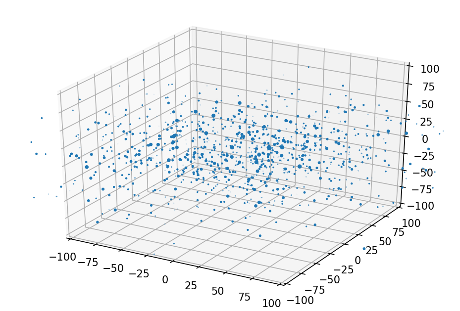

```python
fig = plt.figure()
ax = p3.Axes3D(fig)
ax.set_xlim(-100, 100)
ax.set_ylim(-100, 100)
ax.set_zlim(-100, 100)
m, y0 = initialize_spiral(N, cp)
# Move data back onto CPU and convert to numpy array
x, _ = cp.asnumpy(y0)
ln = ax.scatter(x[:,0], x[:,1], x[:,2], s=cp.asnumpy(m), animated=True, alpha=1)
```

```python
def nbody_df(t, y, acc_f, m):
    x, v = y
    a = acc_f(x, m)
    return np.stack((v, a))
```

For small interaction distances our acceleration functions are numerically unstable, so let's add an $\epsilon$ term to supress erroneous instabilities.

$a_i = \frac{1}{m_i}\sum_{j\neq i}^{N} \frac{G m_i m_j (x_j - x_i)}{\lVert{x_j - x_i}\lVert^3} \approx \sum_{j\neq i}^{N} \frac{G m_j (x_j - x_i)}{{(\lVert{x_j - x_i}\lVert^2 + \epsilon^2)}^{3/2}}$

```python
def vec(x, m, eps=1):
    # determine cpu or gpu based on type (proxy for data location)
    xp = cp.get_array_module(x)

    n = m.size
    # broadcast to simulate (m_i*m_j)/m_j for all i
    M = xp.tile(m.reshape(-1,1), (1,n)).reshape(n,n,1)
    # Tensor outer difference gets displacement vectors between all bodies
    d = x.reshape((1, -1, 3)) - x.reshape((-1, 1, 3))
    # distance
    r = np.linalg.norm(d, axis=2)
    # numerically stabilized component-wise acceleration
    a = (M*d)/np.power(np.expand_dims(r, 2)**2 + eps**2, 3/2)
    return a.sum(axis=1)
```

```python
def erk4_step(f, t, y, h):
    # explicit order 4 Runge-Kutta scheme
    k1 = f(t, y)
    k2 = f(t + h/2., y + h*k1*.5)
    k3 = f(t + h/2., y + h*k2*.5)
    k4 = f(t + h, y + h*k3)
    yn = y + (h/6.)*(k1 + 2.*k2 + 2.*k3 + k4)
    tn = t + h
    return yn, tn
```

```python
def benchmark_erk4_step(m, y, location):
    # Run the solver and take wall-clock reading.
    tstart = time.time()
    erk4_step(lambda t, y: nbody_df(t, y, vec, m), 0, y0, 1e-2)
    # wait for GPU to finish
    cp.cuda.stream.get_current_stream().synchronize()
    tstop = time.time()

    print(f"ODE step runtime {location}: {(tstop - tstart)*1000} milliseconds. ")

N = 1000
m, y0 = initialize_spiral(N, np)
benchmark_erk4_step(m, y0, "CPU")
m, y0 = initialize_spiral(N, cp)
benchmark_erk4_step(m, y0, "GPU")
```

```
ODE step runtime CPU: 312.97874450683594 milliseconds.
ODE step runtime GPU: 14.807939529418945 milliseconds.
```

```python
def solve_ivp(f, y, duration, h=1e-2, frame_keep=1):

    xp = cp.get_array_module(y)

    steps = int(duration / h)
    frame_count = int(steps / frame_keep)

    # reserve storage on GPU (or CPU) for result frames
    ys = xp.empty((frame_count, *y.shape))

    for step in range(steps):
        y, _ = erk4_step(f, 0, y, h)
        if step % frame_keep == 0:
            ys[int(step / frame_keep), :] = y

    # Move data back to CPU
    ys = cp.asnumpy(ys[:,0,:,:])
    return ys
```

```python
duration = 200
frame_keep = 4
h = 1e-2

tstart = time.time()
frames = solve_ivp(lambda t, y: nbody_df(t, y, vec, m), y0, duration=duration, h=h, frame_keep=frame_keep)
tstop = time.time()

print(f"ODE solver runtime: {(tstop - tstart)} seconds. ")
```

```
ODE solver runtime: 203.0437626838684 seconds.
```

```python
from matplotlib.animation import FuncAnimation

def update(x):
    ln._offsets3d = (x[:,0], x[:,1], x[:,2])
    return ln,

ani = FuncAnimation(fig, update, frames=frames, interval=10)
```

[video not shown]

# Power Spectrum

```
(7533, 7533)
```

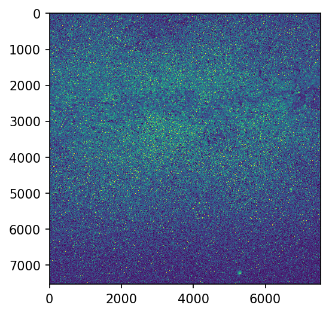

```python
import matplotlib.image as mpimg
import pylab as pl

image = mpimg.imread("slide_images/big_milky_way_blue.png")
print(image.shape)
pl.imshow(image)
```

```python
def benchmark_fft(image, location):
    xp = cp.get_array_module(image)
    tstart = time.time()
    fourier_image = xp.fft.fftn(image)
    cp.cuda.Stream.null.synchronize()
    tstop = time.time()

    print(f"FFT runtime {location}: {tstop - tstart} seconds.")

benchmark_fft(image, "CPU")

image = cp.asarray(image)
benchmark_fft(image, "GPU")
```

```
FFT runtime CPU: 1.5142745971679688 seconds.
FFT runtime GPU: 0.1241309642791748 seconds.
```

## FFT Benchmarks

[figure not shown]

```python
import scipy.stats as stats

xp = cp.get_array_module(image)
fourier_image = xp.fft.fftn(image)
fourier_amplitudes = xp.abs(fourier_image).flatten()
fourier_amplitudes = cp.asnumpy(fourier_amplitudes).flatten()

kfreq = np.fft.fftfreq(image.shape[0])*image.shape[0]
kfreq2D = np.meshgrid(kfreq, kfreq)
knrm = np.sqrt(kfreq2D[0]**2 + kfreq2D[1]**2).flatten()
kbins = np.arange(0.5, 501., 1.)
kvals = 0.5*(kbins[1:] + kbins[:-1])

Abins, _, _ = stats.binned_statistic(knrm, fourier_amplitudes, statistic="mean", bins=kbins)
Abins *= 4.*xp.pi/3.*(kbins[1:]**3 - kbins[:-1]**3)
```

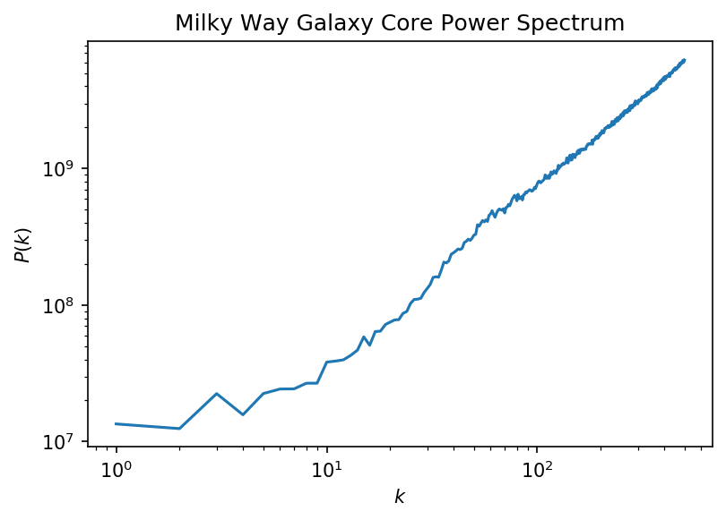

```python
plt.loglog(kvals, Abins)
plt.xlabel("$k$")
plt.ylabel("$P(k)$")
plt.title("Milky Way Galaxy Core Power Spectrum")
plt.show()
```

```python
def blas_cpu(pos, m):

    n = m.size

    # trick: use complex Hermitian to get the packed anti-symmetric
    # outer difference in the imaginary part of the zhpr answer
    # don't want to sum over dimensions yet, therefore must do them one-by-one
    trck = np.zeros((3, n*(n + 1) // 2), complex)
    for a, p in zip(trck, pos.T - 1j):
        # does  a  ->  a + alpha pp^H
        zhpr(
            n,    # matrix dimension
            -2,    # real scalar
            p,    # complex scalar
            a,    # output: packed Hermitian nxn matrix a i.e. n(n+1)/2 vector
            1,    # p stride
            0,    # p offset
            0,    # lower triangular storage
            1    # overwrite, inplace
        )

    # as a by-product we get pos pos^T:
    ppT = trck.real.sum(0) + 6

    # now compute matrix of squared distances ...
    # ... using (A-B)^2 = A^2 + B^2 - 2AB
    # ... that and the outer sum X (+) X.T equals X ones^T + ones X^T
    dspr2(n, -0.5, ppT[np.r_[0, 2:n + 1].cumsum()], np.ones((n, )), ppT, 1, 0,
          1, 0, 0, 1)

    # does  a  ->  a + alpha x y^T + alpha y x^T    in packed symmetric storage
    # scale anti-symmetric differences by distance^-3
    np.divide(trck.imag, ppT*np.sqrt(ppT), where=ppT.astype(bool),
              out=trck.imag)

    # it remains to scale by mass and sum
    # this can be done by matrix multiplication with the vector of m ...
    # ... unfortunately because we need anti-symmetry we need to work
    # with Hermitian storage, i.e. complex numbers, even though the actual
    # computation is only real:
    out = np.zeros((3, n), complex)

    for a, o in zip(trck, out):
        zhpmv(n, 0.5, a, -1j*m, 1, 0, 0, o, 1, 0, 0, 1)
        # multiplies packed Hermitian matrix by vector
    return out.real.T
```